# Craniosynostosis Multivariate Regression Analysis

Ryan Taylor, Joshua Lukemire, and Julia Wrobel

11-1-2024

# Overview

- **Goal: predict volume differences for each region by suture type**
- We use preprocessed Volumetric results from CT and 3D Photometry to create a multivariate regression associating regional volume differences with specific suture fusion diagnoses
  - This model uses a patient’s suture fusion type to generate predictions and uncertainty for their 12 region-specific volume differences from their personalized reference head
- Our model shows a clear and reasonable pattern in volume differences associated with each suture fusion type, so we think we could be ready to develop a clinical paper
- However, a significant percentage of variance remains in the data
  - None of the demographics included in the data explain these residuals
- We have some remaining questions about the construction of the personalized normative reference head volume, and think a better understanding of this would help us to better understand the model’s performance

# Data Description

- We use the Volumetric Results file from 8/6/2024:
  - Each row is one picture
  - Based on the “UID” column, multiple pictures can come from the same patient
  - Demographics include Sex, Race, Ethnicity, Genetic Diagnosis, and Age at image (in days)
  - Separate columns indicate the presence of Metopic, Sagittal, Left coronal, Right coronal, Left lambdoid, and Right Lambdoid fusions
  - Overall Head Volume and Personalized Normative Reference Head Volume are given
  - Region-specific volume differences are given
- We clean the suture type column:
  - If a patient has both left coronal and right coronal sutures, we classify them as “Bicoronal”
  - If they have another combination of multiple sutures, we classify them as “Multiple”
    - We eventually exclude these
  - If they have no sutures, we classify them as “No suture”
    - These are the reference group in our analysis
  - Otherwise, we classify them based on the single suture they have

# Multivariate Regression

- We run a multivariate linear regression model
  - Linear regression provides an estimate of the average head shape for a patient in each suture group
  - We are interested in modeling how regions’ volumes vary together
    - Multivariate regression allows for modeling covariance across regions
      - See appendix for detail
  - Multivariate regression also allows for testing hypotheses about coefficients across regions
  - We can answer “How are volume differences in regions 1, 2, 3, and 4 related between the sagittal group and the metopic group?”

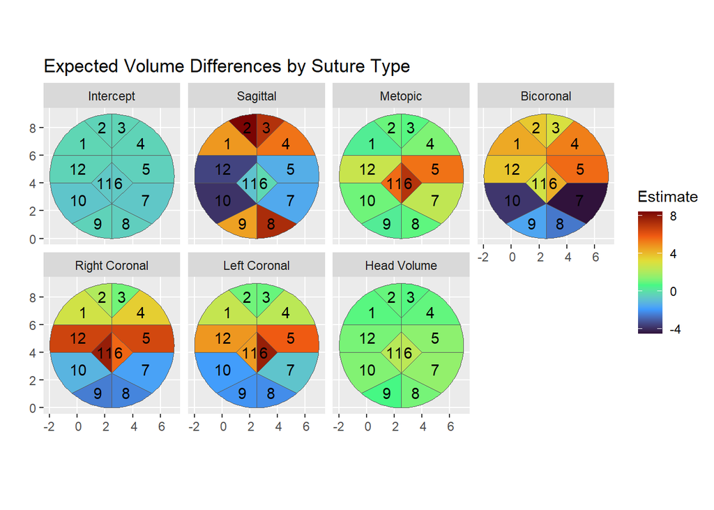

- Therefore, we run the model:
  $$y_i^{(d)} = \beta_0 + \sum_{k = 1}^5 \beta_k
  X_{ik} + \gamma_1 Z_{i1} + \epsilon_i^{(d)}$$
- $y_i^{(d)} =$ Volume Difference for Patient $i$ in region $d$ (mL)
- $X_{ik} =$ Binary indicator variable for Patient $i$’s fusion type: Sagittal, Metopic, Bicoronal, Right Coronal, or Left Coronal
- $Z_{i1} =$ Patient $i$’s Overall Head Volume (mL)

# Model Performance

- $R^2$ ranges from 0.10 to 0.32.

Model Performance Statistics

| Region | RSE | R Squared | Adj. R Squared |
| --- | --- | --- | --- |
| region_1_volume_difference_m_l | 3.078 | 0.277 | 0.275 |
| region_2_volume_difference_m_l | 4.496 | 0.325 | 0.323 |
| region_3_volume_difference_m_l | 3.972 | 0.308 | 0.306 |
| region_4_volume_difference_m_l | 3.670 | 0.261 | 0.26 |
| region_5_volume_difference_m_l | 5.133 | 0.18 | 0.178 |
| region_6_volume_difference_m_l | 6.035 | 0.188 | 0.186 |
| region_7_volume_difference_m_l | 5.944 | 0.106 | 0.104 |
| region_8_volume_difference_m_l | 5.107 | 0.251 | 0.25 |
| region_9_volume_difference_m_l | 3.875 | 0.191 | 0.189 |
| region_10_volume_difference_m_l | 5.847 | 0.128 | 0.126 |
| region_11_volume_difference_m_l | 6.022 | 0.173 | 0.171 |
| region_12_volume_difference_m_l | 4.482 | 0.221 | 0.219 |

# Next steps

- **Questions?**
- Outstanding issues for a paper?

# *Appendix*

- Data questions
- Correlation plots
- Age effects
- Data summaries

# Data Questions

- We created some summaries of the data in order to understand the volume differences (i.e. our outcome variable) better
- Suppose $\boldsymbol{Y}_i = (Y^{(1)}_i, \ Y_i^{(1)}, \ ..., \ Y_i^{(12)})$ is the $12 \times 1$ vector of region-specific volume differences for patient $i$; $V^{(A)}_i$ is patient $i$’s actual overall head volume, and $V^{(R)}_i$ is the volume of the personalized reference head volume for patient $i$. We expected:
  - $\sum_{j=1}^{12} Y_i^{(j)} = V_i^{(A)} - V_i^{(R)}$ for each patient
    - I.e. the sum of the region-specific volume differences is equal to the overall head volume minus the personalized reference head volume
- In the data, we observe that these metrics are similar, but not identical:

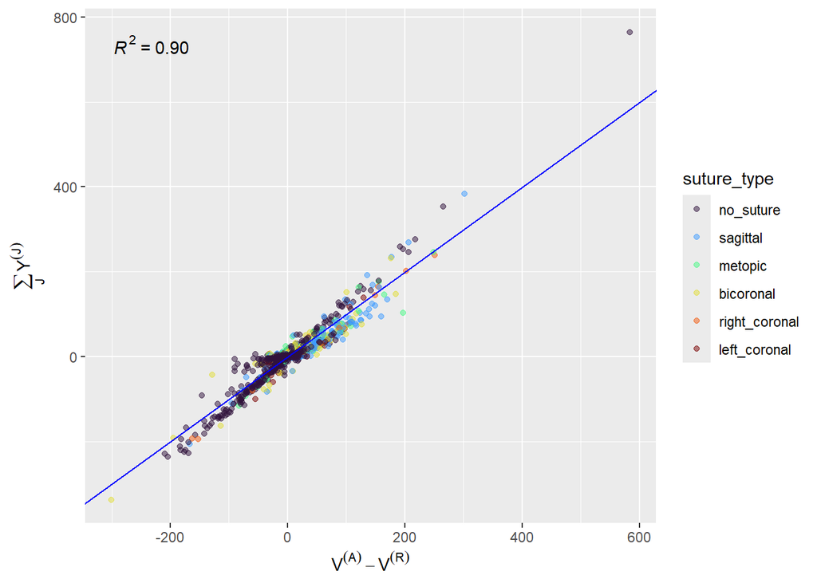

# Correlation Plots

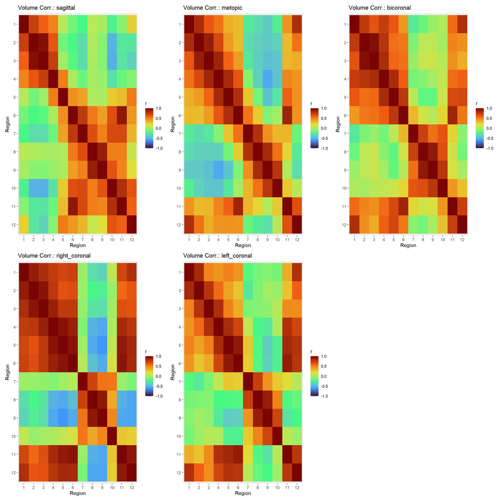

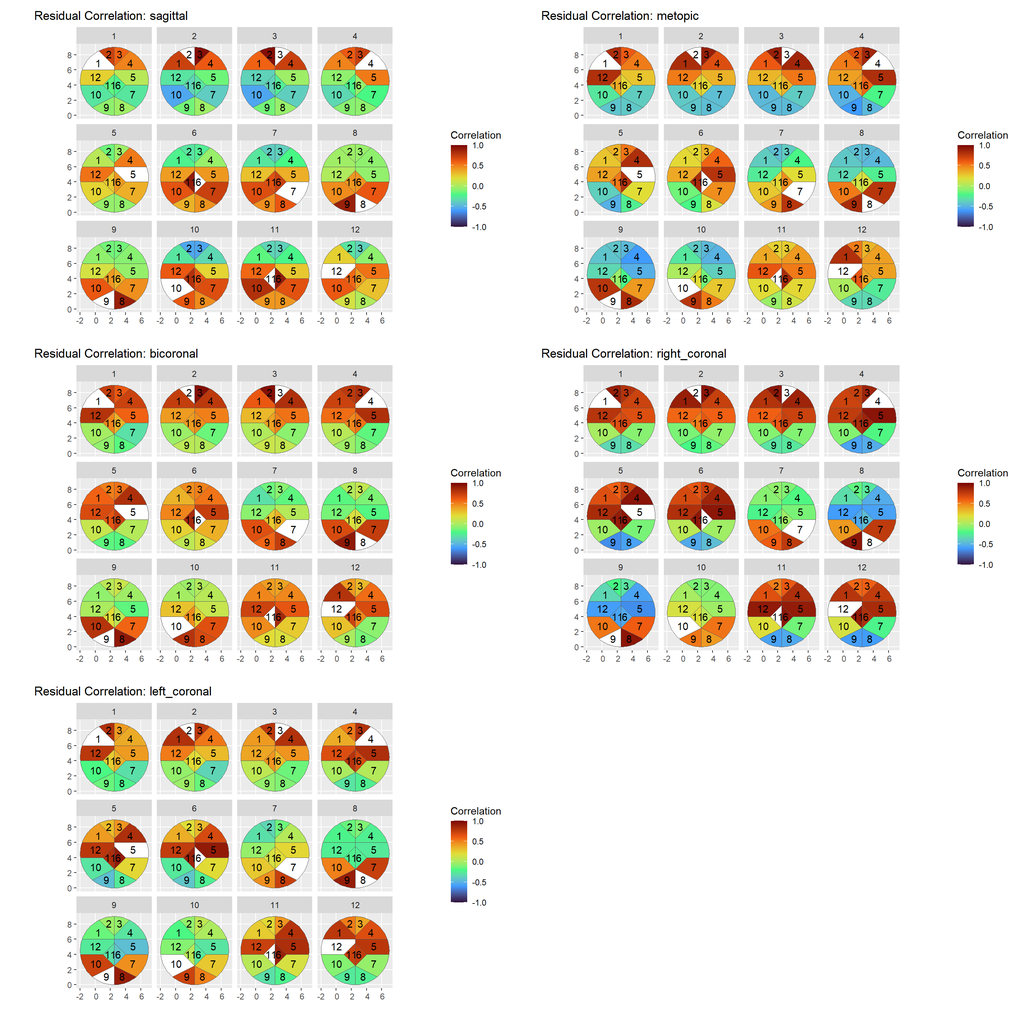

# Age

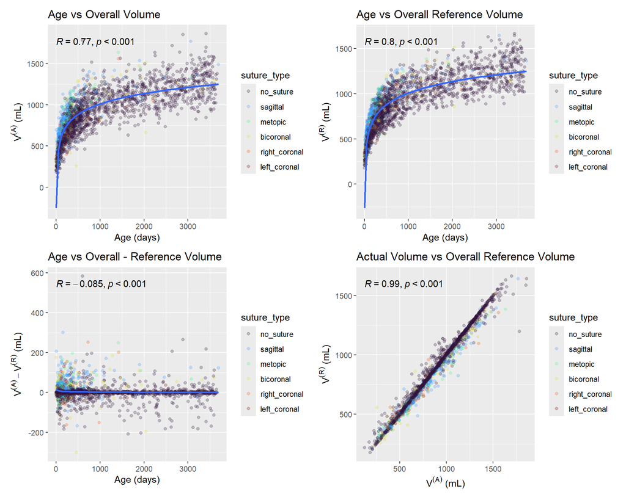

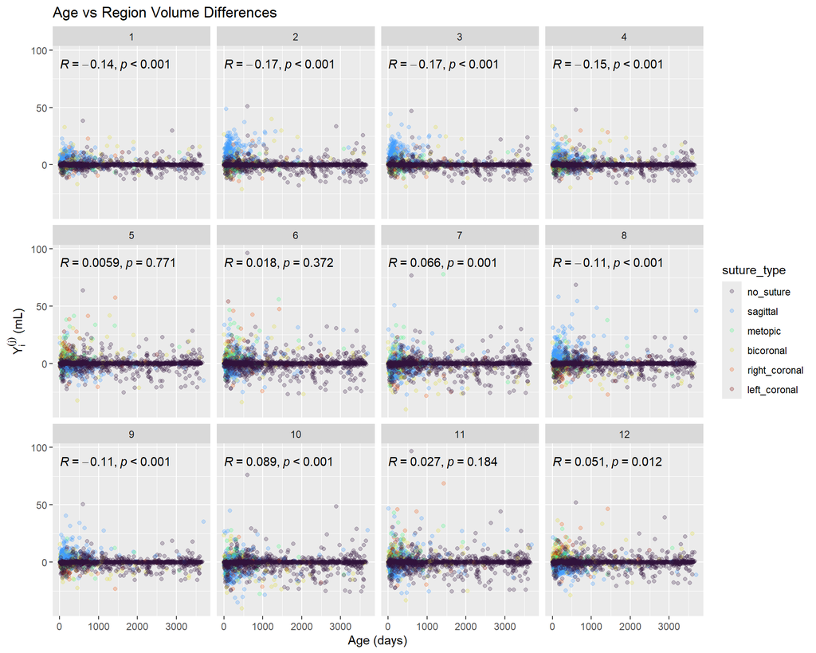

# Age < 1 Year

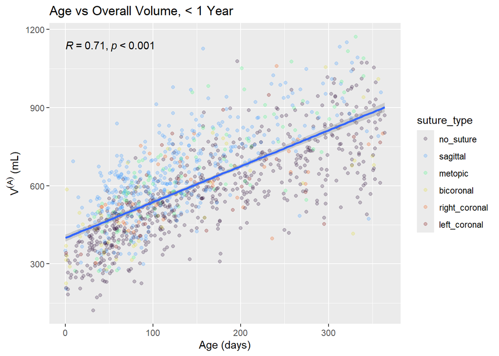

# Volume Difference Distributions

- Volume differences are generally right-tailed, and the distributions look similar across regions. Boxplots show there are only a very small number of outliers pulling the distribution so far out to the right.

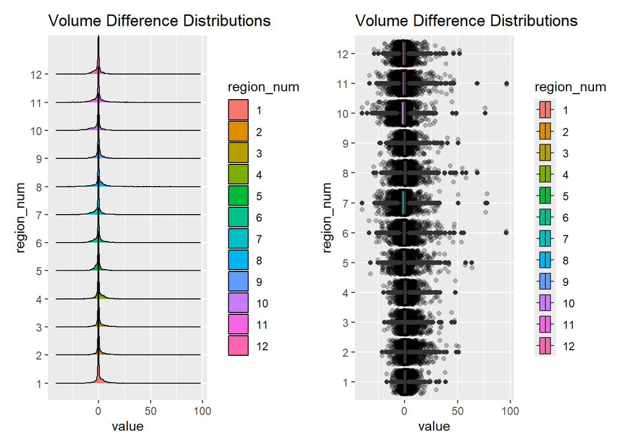

# Data Summary: Multiple Pictures

All pictures and patients

| Rows | 2626 |
| --- | --- |
| Unique Pictures | 2626 |
| Unique Patients | 2464 |

Multiple Pictures

| Suture Fusion | Patients | Max Pics / Patient | Avg Pics / Patient | % of Data |
| --- | --- | --- | --- | --- |
| sagittal | 71 | 5 | 2.23 | 2.88% |
| metopic | 28 | 3 | 2.32 | 1.14% |
| right_coronal | 8 | 4 | 2.50 | 0.32% |
| bicoronal | 7 | 4 | 2.43 | 0.28% |
| multiple | 6 | 3 | 2.17 | 0.24% |
| left_lambdoid | 3 | 3 | 2.33 | 0.12% |
| right_lambdoid | 2 | 3 | 3.00 | 0.08% |
| left_coronal | 1 | 2 | 2.00 | 0.04% |

- A small percentage of patients had multiple visits, but any one patient was seen five times at most
  - This suggests that we cannot do any longitudinal analysis with the data
  - We also find that no patient’s diagnosis changes over time

# Data Summary: Fusions

Suture Representation

Suture Type

Pictures

Patients

% of Patients

% of Included

no_suture

1718

1718

69.7%

70.8%

sagittal

506

419

17.0%

17.3%

metopic

155

118

4.8%

4.9%

bicoronal

93

83

3.4%

3.4%

right_coronal

65

53

2.2%

2.2%

left_coronal

37

36

1.5%

1.5%

multiple

35

28

1.1%

0.0%

left_lambdoid

10

6

0.2%

0.0%

right_lambdoid

7

3

0.1%

0.0%

Total

2626

2464

Sagittal is the most common suture fusion type in the data

Bicoronal fusion is more common than either left or right coronal

Multiple, Left Lambdoid, and Right Lambdoid fusions are very uncommon

Based on these summaries, we exclude Multiple, Left Lambdoid, and Right Lambdoid fusions, and then take the last picture taken chronologically for each patient

# Table 1

|  | no_suture (N=1718) | sagittal (N=419) | metopic (N=118) | bicoronal (N=83) | right_coronal (N=53) | left_coronal (N=36) | Overall (N=2427) |
| --- | --- | --- | --- | --- | --- | --- | --- |
| Image Type |  |  |  |  |  |  |  |
| CT | 1718 (100%) | 222 (53.0%) | 65 (55.1%) | 77 (92.8%) | 41 (77.4%) | 32 (88.9%) | 2155 (88.8%) |
| 3D photo | 0 (0%) | 197 (47.0%) | 53 (44.9%) | 6 (7.2%) | 12 (22.6%) | 4 (11.1%) | 272 (11.2%) |
| Sex |  |  |  |  |  |  |  |
| Female | 783 (45.6%) | 109 (26.0%) | 30 (25.4%) | 43 (51.8%) | 31 (58.5%) | 29 (80.6%) | 1025 (42.2%) |
| Male | 934 (54.4%) | 310 (74.0%) | 88 (74.6%) | 40 (48.2%) | 22 (41.5%) | 7 (19.4%) | 1401 (57.7%) |
| Missing | 1 (0.1%) | 0 (0%) | 0 (0%) | 0 (0%) | 0 (0%) | 0 (0%) | 1 (0.0%) |
| Race |  |  |  |  |  |  |  |
| African or African American | 514 (29.9%) | 33 (7.9%) | 4 (3.4%) | 15 (18.1%) | 4 (7.5%) | 9 (25.0%) | 579 (23.9%) |
| American Indian or Alaska Native | 6 (0.3%) | 5 (1.2%) | 0 (0%) | 1 (1.2%) | 1 (1.9%) | 0 (0%) | 13 (0.5%) |
| Asian | 28 (1.6%) | 40 (9.5%) | 16 (13.6%) | 1 (1.2%) | 2 (3.8%) | 1 (2.8%) | 88 (3.6%) |
| Caucasian | 743 (43.2%) | 255 (60.9%) | 75 (63.6%) | 48 (57.8%) | 28 (52.8%) | 19 (52.8%) | 1168 (48.1%) |
| Native Hawaiian or Other Pacific Islander | 3 (0.2%) | 0 (0%) | 0 (0%) | 0 (0%) | 0 (0%) | 0 (0%) | 3 (0.1%) |
| Missing | 424 (24.7%) | 86 (20.5%) | 23 (19.5%) | 18 (21.7%) | 18 (34.0%) | 7 (19.4%) | 576 (23.7%) |
| Ethnicity |  |  |  |  |  |  |  |
| Hispanic or Latino | 445 (25.9%) | 97 (23.2%) | 29 (24.6%) | 21 (25.3%) | 13 (24.5%) | 6 (16.7%) | 611 (25.2%) |
| Not Hispanic or Latino | 1029 (59.9%) | 282 (67.3%) | 82 (69.5%) | 57 (68.7%) | 33 (62.3%) | 28 (77.8%) | 1511 (62.3%) |
| Missing | 244 (14.2%) | 40 (9.5%) | 7 (5.9%) | 5 (6.0%) | 7 (13.2%) | 2 (5.6%) | 305 (12.6%) |
| Age (days) |  |  |  |  |  |  |  |
| Mean (SD) | 1110 (1090) | 229 (387) | 249 (370) | 609 (856) | 270 (369) | 286 (466) | 868 (1020) |
| Median [Min, Max] | 617 [1.00, 3660] | 124 [0, 3700] | 148 [11.0, 3080] | 193 [1.00, 3600] | 148 [35.0, 2210] | 163 [1.00, 2490] | 379 [0, 3700] |
| Head Volume (mL) |  |  |  |  |  |  |  |
| Mean (SD) | 881 (312) | 712 (238) | 723 (257) | 751 (357) | 683 (239) | 644 (204) | 832 (307) |
| Median [Min, Max] | 899 [122, 1860] | 658 [203, 1770] | 667 [272, 1630] | 676 [225, 1520] | 652 [303, 1560] | 626 [336, 1200] | 807 [122, 1860] |
| Reference Head Volume (mL) |  |  |  |  |  |  |  |
| Mean (SD) | 884 (303) | 688 (216) | 702 (230) | 733 (334) | 662 (201) | 630 (186) | 827 (298) |
| Median [Min, Max] | 905 [179, 1660] | 644 [211, 1640] | 662 [278, 1380] | 692 [226, 1510] | 615 [305, 1360] | 624 [350, 1160] | 808 [179, 1660] |